# Llama stocks: same code, different forecasts

## Llama stocks: same code, different forecasts

CS 301 · Group 6

The Central Bank needs tomorrow’s forecast. Our networks need a group meeting.

## Our data and code

- **160 observations**, split into **120 training / 40 test**
- Inputs: hay price, llama posts, spit incidents, fog, head-llama mood
- Outcome: **price up (1)** or **not up (0)**
- Scale inputs to 0–1; keep split seed **301**
- Train the same network with starting seeds **1–10**

## Our network

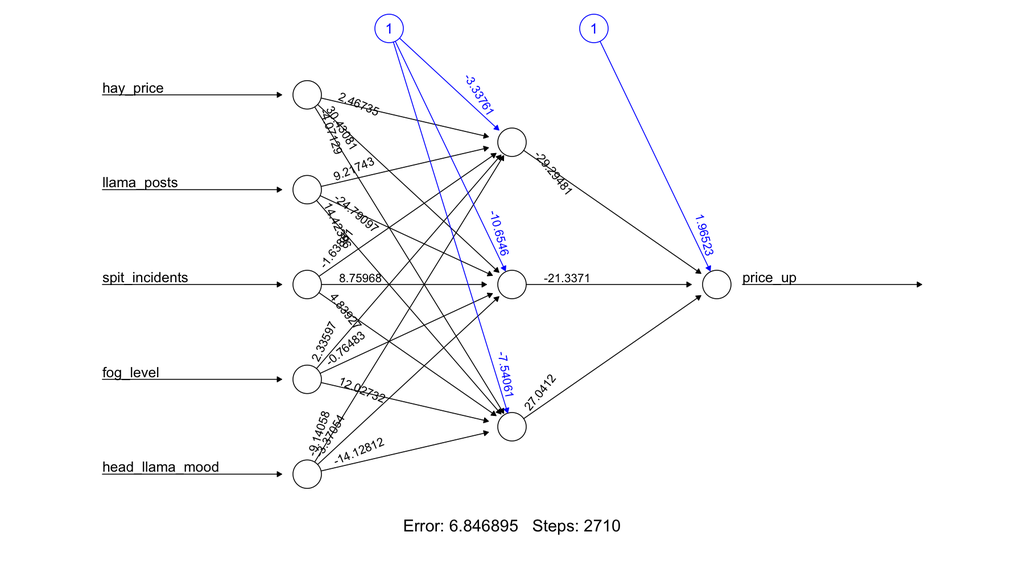

**5 inputs → 3 hidden neurons → 1 output**

Original fit: **85% test accuracy · 85.83% training accuracy**

## Our ten runs

| Seed | Training error | Test accuracy | Tomorrow: P(up) |
| --- | --- | --- | --- |
| 1 | 7.139 | 65.0% | 37.1% |
| 2 | 6.521 | 67.5% | 0.5% |
| 3 | 6.500 | 90.0% | 73.1% |
| 4 | 6.784 | 72.5% | 6.3% |
| 5 | 6.830 | 77.5% | 48.1% |
| 6 | 6.254 | 70.0% | 8.8% |
| 7 | 6.930 | 80.0% | 46.6% |
| 8 | 7.609 | 67.5% | 2.0% |
| 9 | 7.296 | 65.0% | 40.9% |
| 10 | 7.082 | 67.5% | 49.7% |

Training error is the model’s fitting error, not a percentage.

## Accuracy depends on the random start

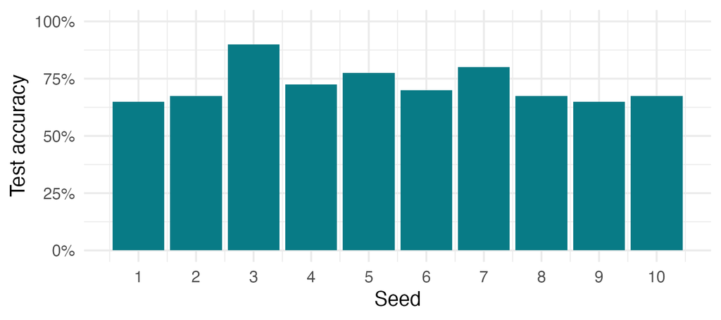

**Worst: 65% · Best: 90% · Mean: 72.25%**

We would report **the mean and range**.

## Tomorrow: mostly agreement, wide variation

**9 “not up” · 1 “up”**

Mean score for a rise: **31.31%**

Range: **0.53–73.06%**

Nine votes out of ten **does not mean 90% confidence**.

## The Bank’s statement

> Nine of our ten networks predict no rise tomorrow, but their predictions vary widely, so the Central Bank considers the forecast uncertain.

To improve trust: **report the spread, test more unseen data, and check consistency across starts**.

**The forecast needs a caveat before it gets a microphone.**